#### Model using Data After 1997 Gives Better Results than My Previous Models

#### 1. Data After 1997

Before 1997, Japanese active population grows. But after 1997, the population steadily decreases. Due to Japan’s low birth rates, together with little effective interventions for changing the status quo, many reports project Japan’s population will continue the downward trend for many years. If we know the population will decline, why don’t we focus on the recent declining population data after 1997.  
The 20% test set data of the entire series start on Sep 2005. In order to match the starting data for forecasting, I reserve 47.7% of the data after 1997 for training. So the training set starts in Jan 1997 and ends in Aug 2005. The test set starts in Sep 2005 annd ends in Feb 2015.

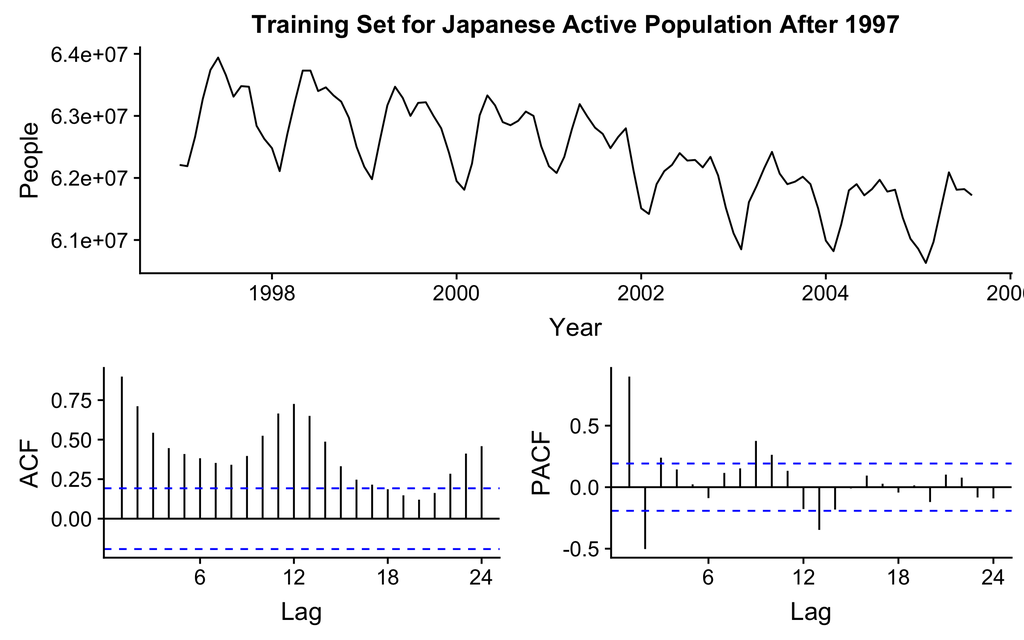

This chart shows a decline trend with seasonality. The ACF and PACF suggests this series might have an AR(2) effect. This series doesn’t pass the ADF test of stationarity, nor the Box-Ljung test of independence up to 24 lags.

#### 2. Models

Since the downward trend looks quite linear, I model the series with a linear trend and a quadratic trend. The RMSE comparison tables are below.

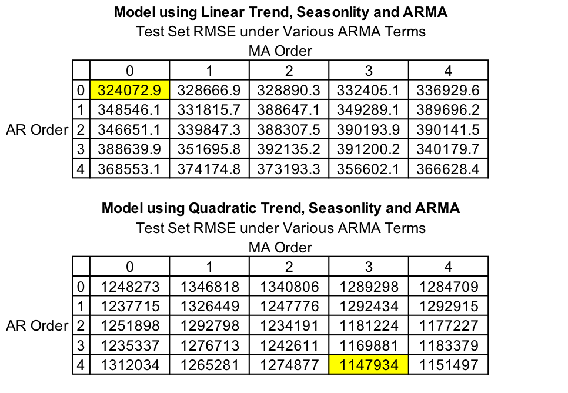

Linear trend with seasonality has the lowest RMSE, 324 thousand people. This value is smaller than my previous models’.

#### 3. Analyze Model: Linear Trend with Seasonality

Although this model has the best RMSE, its residuals don’t pass the ADF test of stationarity, nor the Box-Ljung test of independence up to 24 lags. Additionally, the ACF and PACF suggest some ARMA effects.

```
                             Estimate  Std. Error  z value  Pr(>|z|)
intercept                  63103090.28    74796.36 843.6653 < 2.2e-16 ***
JNPopAfter97Trend.TrainSet   -19918.34      619.06 -32.1754 < 2.2e-16 ***
Jan                         -407091.69    91968.68  -4.4264 9.581e-06 ***
Feb                         -563840.02    91960.12  -6.1314 8.713e-10 ***
Mar                          -58366.13    91971.56  -0.6346    0.5257
Apr                          464885.55    91948.28   5.0559 4.283e-07 ***
May                          821470.55    91928.83   8.9359 < 2.2e-16 ***
Jun                          802500.00    91905.89   8.7318 < 2.2e-16 ***
Jul                          632418.34    91924.71   6.8797 5.996e-12 ***
Aug                          614558.90    91934.05   6.6848 2.313e-11 ***
Sep                          577744.98    94603.92   6.1070 1.015e-09 ***
Oct                          632663.32    94617.56   6.6865 2.285e-11 ***
Nov                          416331.66    94582.10   4.4018 1.074e-05 ***
---
Signif. codes:  0 ‘***’ 0.001 ‘**’ 0.01 ‘*’ 0.05 ‘.’ 0.1 ‘ ’ 1

AIC= 2850.337 SIC= 2887.358
```

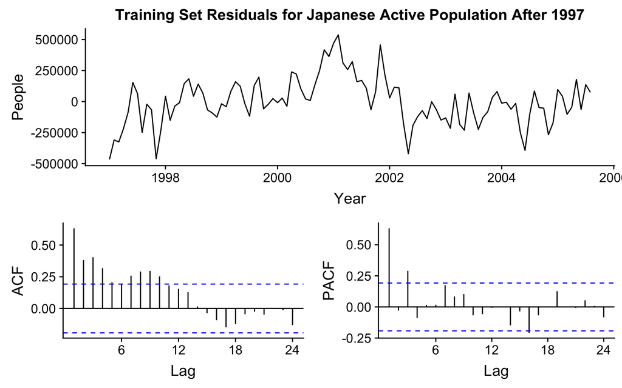

#### 4. Forecast

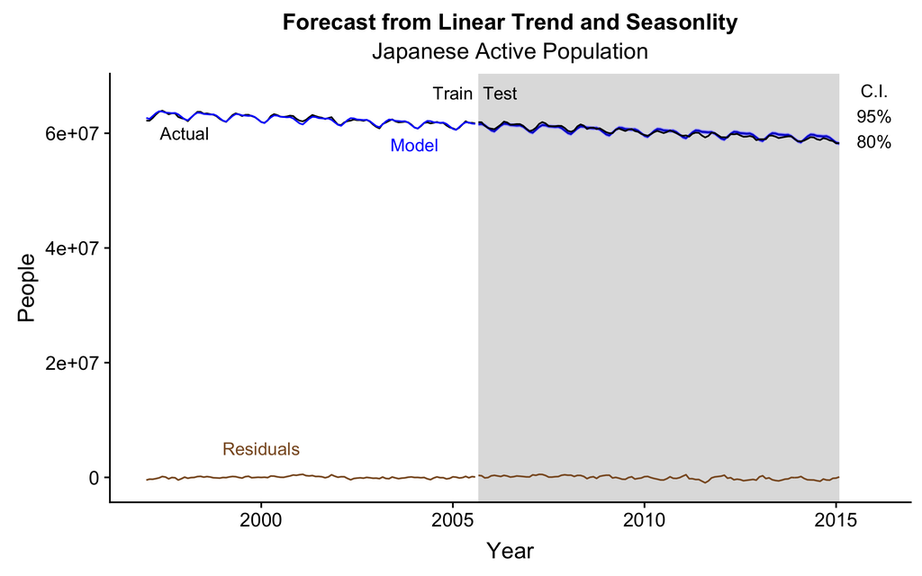

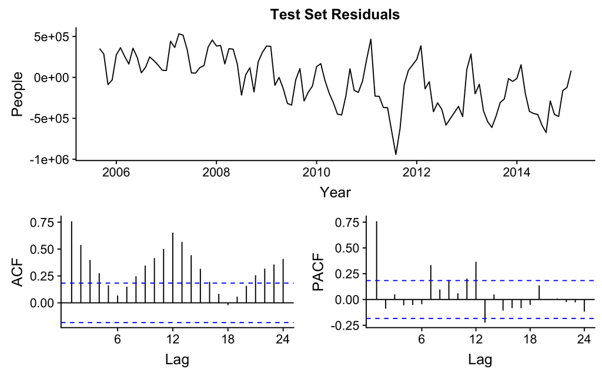

The residuals don’t pass the ADF test of stationarity, nor the Box-Ljung test of independence up to 24 lags. Additionally, the ACF and PACF suggest some ARMA effects.

```
                        ME     RMSE      MAE           MPE      MAPE      MASE
Training set -1.269464e-07 189092.1 144774.2 -0.0009173333 0.2319000 0.5568237
Test set     -5.264078e+04 324072.9 271766.6 -0.0921085044 0.4527358 1.0452563
                  ACF1 Theil's U
Training set 0.6319586        NA
Test set     0.7586944  1.095564
```

Next, I will continue checking out the group’s models’ RMSEs, and model the new data after they are posted.

rmarkdown::render(“Post3U4IA.Rmd”)